# Stat400Project

JamesTondt, Zach Lees, Kyler

2023-11-29

## Front Matter

```r
#Libraries
library(tidyverse)
library(readr)
library(dplyr)
library(lme4)
#Import Data
#C:/Users/20lee/Downloads/application_data.csv/application_data.csv
Credit_card_fraud <- read_csv("C:/Users/kyler/Downloads/application_data.csv (1).zip")
```

# Part 1

# Research Data Information

Use data from:

https://www.kaggle.com/datasets/mishra5001/credit-card/data?select=application_data.csv

https://www.kaggle.com/datasets/mishra5001/credit-card/data?select=columns_description.csv

The data presented provides information about a client with potential credit fraud. The file includes 122 variables that are a mix of binomial and categorical. The data provided is found on kaggle by Mishra5001 and was updated 4 years ago.

Response: TARGET(binary)

Descriptions: TARGET: client with reported payment difficulties (this variable will represent credit fraud if positive)

CODE_GENDER: Gender of the client

AMT_INCOME_TOTAL: Income of the client

AMT_CREDIT: Credit amount of the loan

Research Question: Are females at a higher risk of defaulting?/Does Gender have an effect on the likelihood of defaulting

# Research Question Data Analysis

Are females at a higher risk of defaulting on loans? Does Gender have an effect on the likelihood of defaulting when controlling for their total income, credit loans, and client status for credit applications.

```r
# Create a new data frame and clean data
CCF2 <-
  Credit_card_fraud %>%
  select(TARGET, CODE_GENDER, AMT_INCOME_TOTAL, AMT_CREDIT, NAME_INCOME_TYPE, NAME_EDUCATION_TYPE, NAME_FAMILY_STATUS, NAME_HOUSING_TYPE) %>%
    filter(CODE_GENDER != "XNA") %>%    # only using M and F
    na.omit(CCF2)   # remove any missing values

# create indicator variable for GENDER and TARGET
CCF2 <- CCF2 %>%
  mutate(is_female = ifelse(CODE_GENDER == "F", 1, 0), TargetYes = ifelse(TARGET == 1,"Yes","No"))
```

```r
str(CCF2)
```

```
## tibble [307,507 × 10] (S3: tbl_df/tbl/data.frame)
##  $ TARGET             : num [1:307507] 1 0 0 0 0 0 0 0 0 0 ...
##  $ CODE_GENDER        : chr [1:307507] "M" "F" "M" "F" ...
##  $ AMT_INCOME_TOTAL   : num [1:307507] 202500 270000 67500 135000 121500 ...
##  $ AMT_CREDIT         : num [1:307507] 406598 1293503 135000 312683 513000 ...
##  $ NAME_INCOME_TYPE   : chr [1:307507] "Working" "State servant" "Working" "Working" ...
##  $ NAME_EDUCATION_TYPE: chr [1:307507] "Secondary / secondary special" "Higher education" "Secondary / secondary special" "Secondary / secondary special" ...
##  $ NAME_FAMILY_STATUS : chr [1:307507] "Single / not married" "Married" "Single / not married" "Civil marriage" ...
##  $ NAME_HOUSING_TYPE  : chr [1:307507] "House / apartment" "House / apartment" "House / apartment" "House / apartment" ...
##  $ is_female          : num [1:307507] 0 1 0 1 0 0 1 0 1 0 ...
##  $ TargetYes          : chr [1:307507] "Yes" "No" "No" "No" ...
```

```r
summary(CCF2)
```

```
##      TARGET        CODE_GENDER        AMT_INCOME_TOTAL      AMT_CREDIT
##  Min.   :0.00000   Length:307507      Min.   :    25650   Min.   :  45000
##  1st Qu.:0.00000   Class :character   1st Qu.:   112500   1st Qu.: 270000
##  Median :0.00000   Mode  :character   Median :   147150   Median : 513531
##  Mean   :0.08073                      Mean   :   168798   Mean   : 599029
##  3rd Qu.:0.00000                      3rd Qu.:   202500   3rd Qu.: 808650
##  Max.   :1.00000                      Max.   :117000000   Max.   :4050000
##  NAME_INCOME_TYPE   NAME_EDUCATION_TYPE NAME_FAMILY_STATUS NAME_HOUSING_TYPE
##  Length:307507      Length:307507       Length:307507      Length:307507
##  Class :character   Class :character    Class :character   Class :character
##  Mode  :character   Mode  :character    Mode  :character   Mode  :character
##
##
##
##    is_female       TargetYes
##  Min.   :0.0000   Length:307507
##  1st Qu.:0.0000   Class :character
##  Median :1.0000   Mode  :character
##  Mean   :0.6584
##  3rd Qu.:1.0000
##  Max.   :1.0000
```

# Univariate Analysis and Multivairate Analysis

Target is our response variable, this is whether the client was reported to have payment difficulties. For study purposes TargetYes will determine if the client is determined to have defaulted (yes) or not (no).

Based upon a quick analysis of this graph, most of the data collected shows that TargetYes does not hold the vast majority of responses shown for default detection. This means that most of the clients, based upon the data, collected may not be subject to defaulting and that we can continue our analysis further to see if Target will be a good response variable to our research question.

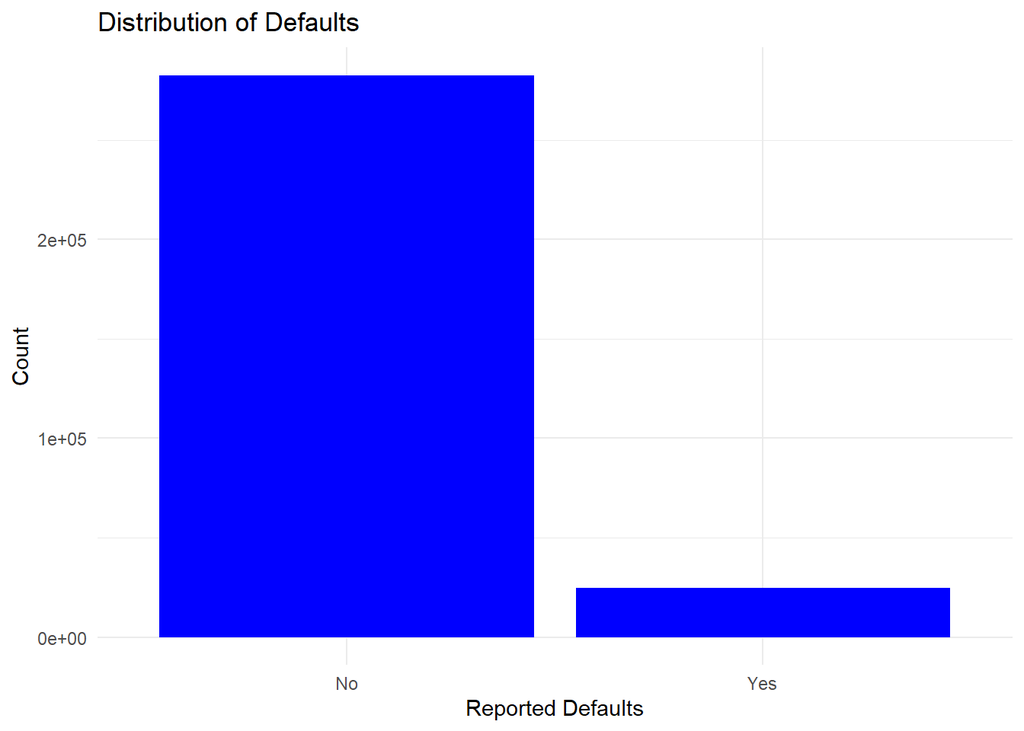

```r
# Barplot for Credit Fraud distribution
ggplot(CCF2, aes(x = TargetYes)) +
  geom_bar(fill = "blue") +
  labs(title = "Distribution of Defaults",
       x = "Reported Defaults",
       y = "Count") +
  theme_minimal()
```

Continuing on with our research, we created a graph that shows the distribution of Gender (male or female) to observe the split between genders collected and reported defaults.

Based upon the graph, we can say that about twice the amount of clients reported to be females verses males had no reported default. However, from further observation, we can see that females have a slightly higher count than males for reported default.s. Continuing forward in our data analysis we will observe other relationships between the variables.

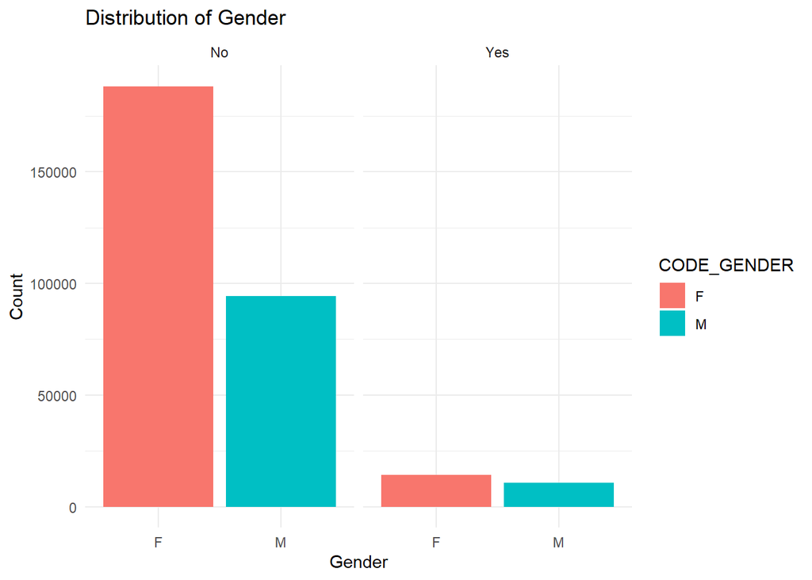

```r
# Barplot for Gender distribution
ggplot(CCF2, aes(x = CODE_GENDER, fill = CODE_GENDER)) +
  geom_bar() +
  facet_wrap(vars(TargetYes))+
  labs(title = "Distribution of Gender",
       x = "Gender",
       y = "Count",
       color = "Gender") +
  theme_minimal()
```

Next we will oserve the relationship between total income and gender. Due to an error in the graph, there may be an incorrectly entered point. Removing any data exceeding an income of 1,000,000 would keep our data from having errors or excessive outliers. We will set a maximum income value of 1,000,000 to clean our data.

Looking at the data comparing total income and the amount of credit fraud reported by gender, we can see that females typically show a pattern to have more reported defaults than the males do with the same to similar total incomes. Looking at this graph we have to keep in mind that more females than males were also surveyed, so this graph alone is not enough to provide enough evidence to support our research statement.

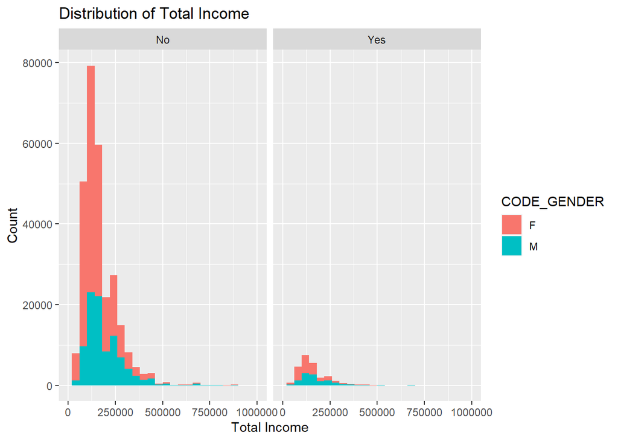

```r
# Histogram for Total Income
ggplot(CCF2, aes(x = AMT_INCOME_TOTAL, fill = CODE_GENDER)) +
  geom_histogram(binwidth = 40000) +
  facet_wrap(vars(TargetYes))+
  labs(title = "Distribution of Total Income",
       x = "Total Income",
       y = "Count",
       color = "Gender") +
  coord_cartesian(xlim = c(0, 1000000))
```

```r
# Remove income past 1,000,000
CCF2 <- CCF2 %>% filter(AMT_INCOME_TOTAL < 1000000)
```

Comparing the graphs for Total Income and Credit amount, the graphs seem to be very similar. Thus it is fare to consider the fact that the credit amount of a loan is dependent on the house income and based upon the data is closely related to the same amount.

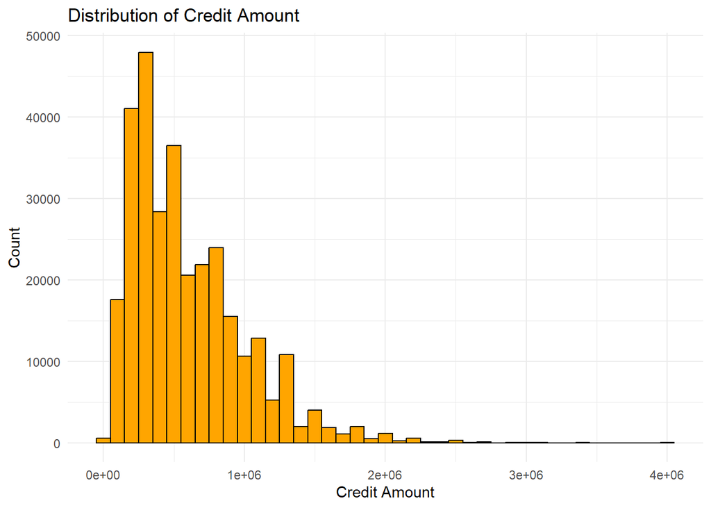

```r
# Histogram for Credit Amount
ggplot(CCF2, aes(x = AMT_CREDIT)) +
  geom_histogram(binwidth = 100000, fill = "orange", color = "black") +
  labs(title = "Distribution of Credit Amount",
       x = "Credit Amount",
       y = "Count") +
  theme_minimal()
```

For a categorical and quantitative variable, we want to create side-by-side boxplots and look at summary statistics.

Interestingly we have found that males have higher income on average in each respective quarterly. Income doesn’t appear to be a very strong predictor for determining if a client defaulted or not.

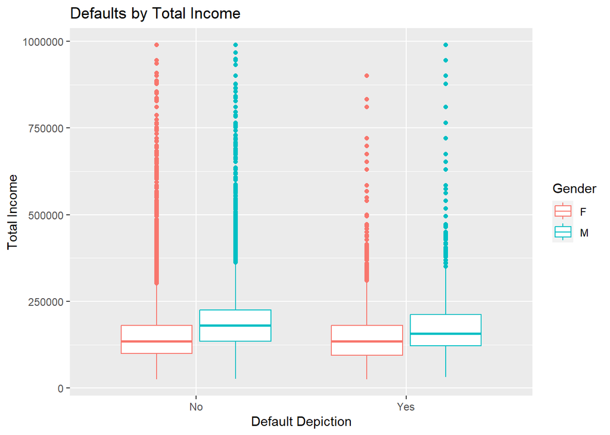

```r
# Scatterplot for Credit Fraud by Total Income
ggplot(CCF2, aes(x = TargetYes, y = AMT_INCOME_TOTAL, color = CODE_GENDER)) +
  geom_boxplot() +
  labs(title = "Defaults by Total Income",
       y = "Total Income",
       x = "Default Depiction",
       color = "Gender")
```

```r
CCF2 %>%
  group_by(TargetYes) %>%
  summarize(meanMath = mean(AMT_INCOME_TOTAL),
            medianMath = median(AMT_INCOME_TOTAL),
            sdMath = sd(AMT_INCOME_TOTAL), count = n())
```

```
## # A tibble: 2 × 5
##   TargetYes meanMath medianMath sdMath  count
##   <chr>        <dbl>      <dbl>  <dbl>  <int>
## 1 No         167791.     148500 90300. 282445
## 2 Yes        160238.     135000 80988.  24812
```

The boxplots between male and female regarding if they have reported default or not in the data don’t appear to be very different for credit amount. Credit amount may not be a strong predictor for determining if a client defaulted or not. This could be because the credit amount given is not sex dependent, so males and females recieve credit on the same rate based upon thier income.

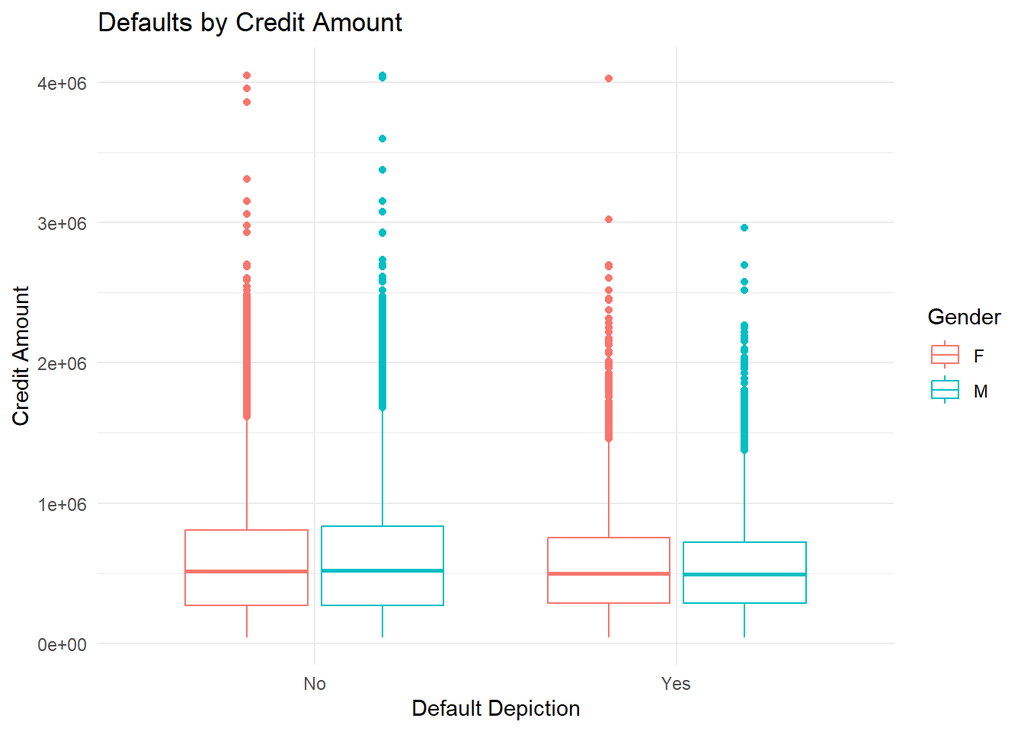

```r
# Scatterplot for Credit Fraud by Credit Amount
ggplot(CCF2, aes(x = TargetYes, y = AMT_CREDIT, color = CODE_GENDER)) +
  geom_boxplot() +
  labs(title = "Defaults by Credit Amount",
       y = "Credit Amount",
       x = "Default Depiction",
       color = "Gender") +
  theme_minimal()
```

```r
CCF2 %>%
  group_by(TargetYes) %>%
  summarize(meanMath = mean(AMT_CREDIT),
            medianMath = median(AMT_CREDIT),
            sdMath = sd(AMT_CREDIT))
```

```
## # A tibble: 2 × 4
##   TargetYes meanMath medianMath  sdMath
##   <chr>        <dbl>      <dbl>   <dbl>
## 1 No         602172.     517500 406240.
## 2 Yes        557584.     497520 346207.
```

Next we create a graph to show the realtion between credit fraud and income type.

Based upon the graph we can consider that there is a relationship between income type and defaulting.

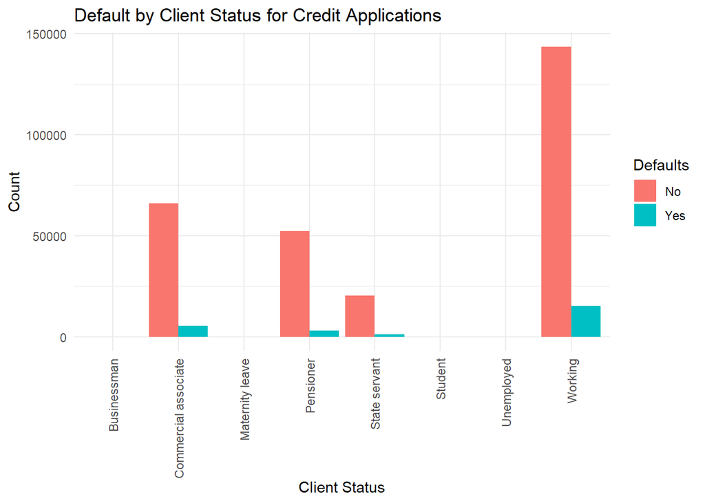

```r
# Barplot for Credit Fraud by Client Status
ggplot(CCF2, aes(x = NAME_INCOME_TYPE, fill = factor(TargetYes))) +
  geom_bar(position = "dodge") +
  labs(title = "Default by Client Status for Credit Applications",
       x = "Client Status",
       y = "Count",
       fill = "Defaults") +
  theme_minimal() +
  theme(axis.text.x = element_text(angle = 90, vjust = 0.5, hjust=1))
```

For further analysis we will create a a model and test the variables’ correlations to TargetYes and form a conclusion to our research question: Are females at a higher risk of credit fraud?/Does Gender have an effect on the likelihood of credit fraud when controlling for their total income, credit loans, and client status for credit applications.

# Analysis

We want to analyze the model including all of our variables versus the reduced model, which doesn’t include gender.

Since the difference between these two is only one variable, we can either do a Wald Test or a Drop-in-Deviance Test. We will do a Drop-in-Deviance Test.

```r
#makes models
model <- glm(TARGET ~ AMT_CREDIT + AMT_INCOME_TOTAL + NAME_INCOME_TYPE + CODE_GENDER, family = binomial, data = CCF2)
model_reduced <- glm(TARGET ~ AMT_CREDIT + AMT_INCOME_TOTAL + NAME_INCOME_TYPE, family = binomial, data = CCF2)

#compares models
anova(model_reduced, model, test = "Chisq")
```

```
## Analysis of Deviance Table
##
## Model 1: TARGET ~ AMT_CREDIT + AMT_INCOME_TOTAL + NAME_INCOME_TYPE
## Model 2: TARGET ~ AMT_CREDIT + AMT_INCOME_TOTAL + NAME_INCOME_TYPE + CODE_GENDER
##   Resid. Df Resid. Dev Df Deviance  Pr(>Chi)
## 1    307247     170777
## 2    307246     170020  1   756.44 < 2.2e-16 ***
## ---
## Signif. codes:  0 '***' 0.001 '**' 0.01 '*' 0.05 '.' 0.1 ' ' 1
```

```r
summary(model)
```

```
##
## Call:
## glm(formula = TARGET ~ AMT_CREDIT + AMT_INCOME_TOTAL + NAME_INCOME_TYPE +
##     CODE_GENDER, family = binomial, data = CCF2)
##
## Deviance Residuals:
##     Min       1Q   Median       3Q      Max
## -1.0549  -0.4426  -0.3991  -0.3373   2.7207
##
## Coefficients:
##                                        Estimate Std. Error z value Pr(>|z|)
## (Intercept)                          -1.106e+01  6.449e+01  -0.172    0.864
## AMT_CREDIT                           -1.952e-07  1.910e-08 -10.216   <2e-16 ***
## AMT_INCOME_TOTAL                     -1.271e-06  9.265e-08 -13.723   <2e-16 ***
## NAME_INCOME_TYPECommercial associate  8.765e+00  6.449e+01   0.136    0.892
## NAME_INCOME_TYPEMaternity leave       1.091e+01  6.449e+01   0.169    0.866
## NAME_INCOME_TYPEPensioner             8.389e+00  6.449e+01   0.130    0.897
## NAME_INCOME_TYPEState servant         8.501e+00  6.449e+01   0.132    0.895
## NAME_INCOME_TYPEStudent              -4.391e-01  7.935e+01  -0.006    0.996
## NAME_INCOME_TYPEUnemployed            1.070e+01  6.449e+01   0.166    0.868
## NAME_INCOME_TYPEWorking               8.968e+00  6.449e+01   0.139    0.889
## CODE_GENDERM                          3.858e-01  1.391e-02  27.727   <2e-16 ***
## ---
## Signif. codes:  0 '***' 0.001 '**' 0.01 '*' 0.05 '.' 0.1 ' ' 1
##
## (Dispersion parameter for binomial family taken to be 1)
##
##     Null deviance: 172436  on 307256  degrees of freedom
## Residual deviance: 170020  on 307246  degrees of freedom
## AIC: 170042
##
## Number of Fisher Scoring iterations: 10
```

```r
summary(model_reduced)
```

```
##
## Call:
## glm(formula = TARGET ~ AMT_CREDIT + AMT_INCOME_TOTAL + NAME_INCOME_TYPE,
##     family = binomial, data = CCF2)
##
## Deviance Residuals:
##     Min       1Q   Median       3Q      Max
## -1.0656  -0.4504  -0.4089  -0.3457   2.6533
##
## Coefficients:
##                                        Estimate Std. Error z value Pr(>|z|)
## (Intercept)                          -1.096e+01  6.508e+01  -0.168    0.866
## AMT_CREDIT                           -2.284e-07  1.908e-08 -11.971   <2e-16 ***
## AMT_INCOME_TOTAL                     -7.727e-07  8.899e-08  -8.683   <2e-16 ***
## NAME_INCOME_TYPECommercial associate  8.745e+00  6.508e+01   0.134    0.893
## NAME_INCOME_TYPEMaternity leave       1.083e+01  6.509e+01   0.166    0.868
## NAME_INCOME_TYPEPensioner             8.317e+00  6.508e+01   0.128    0.898
## NAME_INCOME_TYPEState servant         8.447e+00  6.508e+01   0.130    0.897
## NAME_INCOME_TYPEStudent              -3.602e-01  7.992e+01  -0.005    0.996
## NAME_INCOME_TYPEUnemployed            1.066e+01  6.508e+01   0.164    0.870
## NAME_INCOME_TYPEWorking               8.968e+00  6.508e+01   0.138    0.890
## ---
## Signif. codes:  0 '***' 0.001 '**' 0.01 '*' 0.05 '.' 0.1 ' ' 1
##
## (Dispersion parameter for binomial family taken to be 1)
##
##     Null deviance: 172436  on 307256  degrees of freedom
## Residual deviance: 170777  on 307247  degrees of freedom
## AIC: 170797
##
## Number of Fisher Scoring iterations: 10
```

1. Hypotheses
- Null Hypothesis: $H_0: \beta_{GENDER} = 0$ Implied model:
  $$log(\frac{p_i}{1-p_i}) = \beta_{0} + \beta_{1}
  x_{i,CREDIT} + \beta_{2} x_{i,INCOME_TOTAL} + \beta_{3}
  x_{i,INCOME_TYPE} + \epsilon_{i}$$
- Alternative Hypothesis: $H_1: \beta_{GENDER} \ne 0$ Implied model:
  $$log(\frac{p_i}{1-p_i}) = \beta_{0} + \beta_{1}
  x_{i,CREDIT} + \beta_{2} x_{i,INCOME_TOTAL} + \beta_{3}
  x_{i,INCOME_TYPE} + \beta_{4} x_{i,GENDER} + \epsilon_{i}$$
2. Test Statistic: Drop-in-deviance = 756.44
3. p-value : $p =< 2.2e-16$
4. Decision: Reject $H_0$. Since the p-value < 0.05, reject $H_0$.
5. Conclusion: We will use the model with the variable for gender.

Looking at our model, we can see that the gender being male is positive. This means that the gender being female is a negative predictor. A negative predictor lowers our Target value, which represents the likelihood of a client defaulting or not. If someone is female, they have a lower likelihood of defaulting on a payment.

We are 95% confidence that for CODE_GENDERM (Male), the defaults will increase by between 1.431200 and 1.511436, assuming all other variables are controlled in this model. Males have a greater odds of defaulting compared to females.

```r
#CI
exp(confint(model, "CODE_GENDERM", level = 0.95))
```

```
##    2.5 %   97.5 %
## 1.431200 1.511436
```

From backward selection, we can see that none of the predictors we have are eliminated. This means that all of them are statistically significant. This reaffirms our drop-in-deviance test, where we were testing if a client being male or female was significant for determining defaults.

```r
#Perform backward selection
stats::step(model,
            scope = list(lower=~1, upper=model),
            data = CCF2,
            direction = 'backward')
```

```
## Start:  AIC=170042.3
## TARGET ~ AMT_CREDIT + AMT_INCOME_TOTAL + NAME_INCOME_TYPE + CODE_GENDER
##
##                    Df Deviance    AIC
## <none>                  170020 170042
## - AMT_CREDIT        1   170127 170147
## - AMT_INCOME_TOTAL  1   170219 170239
## - CODE_GENDER       1   170777 170797
## - NAME_INCOME_TYPE  7   171045 171053
```

```
##
## Call:  glm(formula = TARGET ~ AMT_CREDIT + AMT_INCOME_TOTAL + NAME_INCOME_TYPE +
##     CODE_GENDER, family = binomial, data = CCF2)
##
## Coefficients:
##                          (Intercept)                            AMT_CREDIT
##                           -1.106e+01                            -1.952e-07
##                     AMT_INCOME_TOTAL  NAME_INCOME_TYPECommercial associate
##                           -1.271e-06                             8.765e+00
##      NAME_INCOME_TYPEMaternity leave             NAME_INCOME_TYPEPensioner
##                            1.091e+01                             8.389e+00
##        NAME_INCOME_TYPEState servant               NAME_INCOME_TYPEStudent
##                            8.501e+00                            -4.391e-01
##           NAME_INCOME_TYPEUnemployed               NAME_INCOME_TYPEWorking
##                            1.070e+01                             8.968e+00
##                         CODE_GENDERM
##                            3.858e-01
##
## Degrees of Freedom: 307256 Total (i.e. Null);  307246 Residual
## Null Deviance:       172400
## Residual Deviance: 170000    AIC: 170000
```

# Part 2

Research Question: Does the association between meaning and reaction time differ based on old age.

Response: Reaction time (rt_sec)

Level 1 observational unit: Reaction Level 2 observational unit: Participant

Level 1 covariates: meaning, salience Level 2 covariates: sex, age, oldage, yrs65

Fixed Effects: meaning, oldage Random Effects: id

```r
reaction <- read.csv("https://raw.githubusercontent.com/mkshaw/learn-mlms/master/data/hoffman2007.csv")
```

# Univariate Analysis

Many of the reaction times are very quick, withing the first 0 to 5 seconds, and it is right skewed.

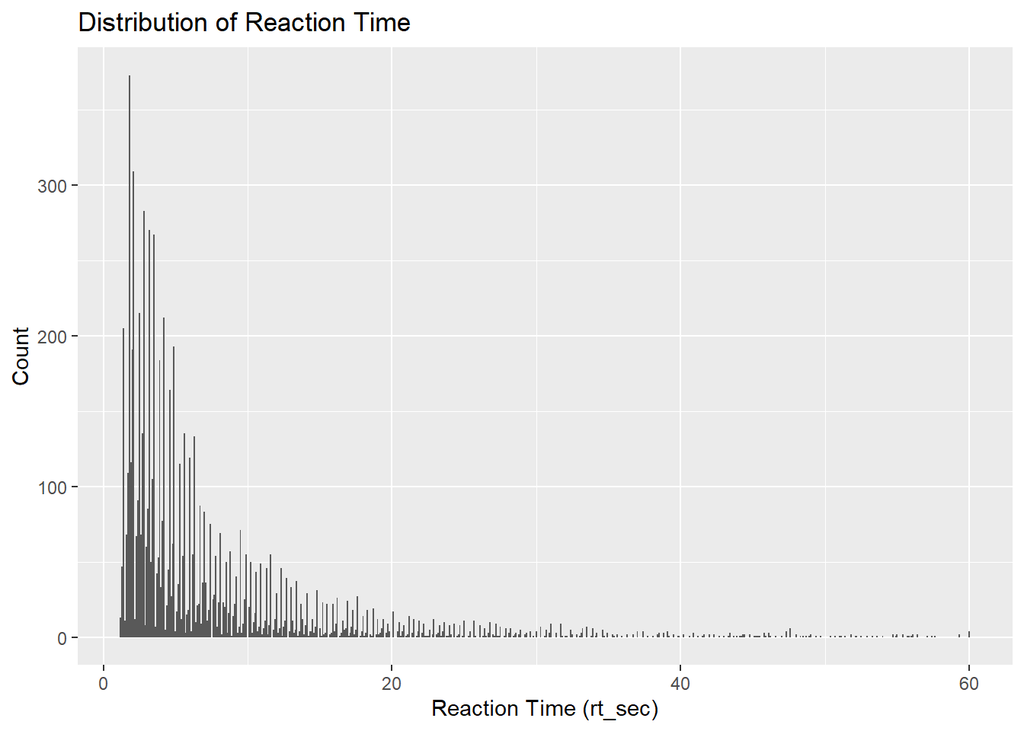

```r
# analysis for rt_sec
ggplot(reaction, aes(x = rt_sec)) +
  geom_histogram(binwidth = 0.1) +
  labs(title = "Distribution of Reaction Time",
       x = "Reaction Time (rt_sec)",
       y = "Count")
```

This is a numerical representation of how useful the picture is. It is interesting to note that it is not an equal spread, it has large amounts in 0 and 4.

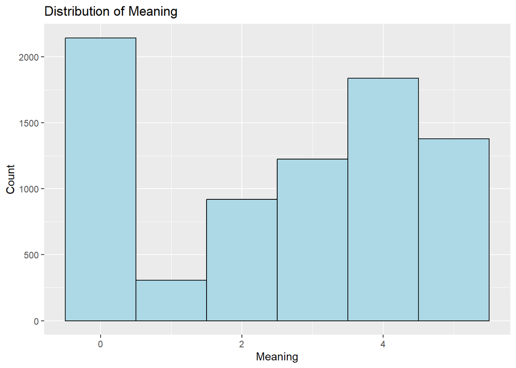

```r
#analysis for meaning
ggplot(reaction, aes(x = meaning)) +
  geom_histogram(binwidth = 1, fill = "lightblue", color = "black") +
  labs(title = "Distribution of Meaning",
       x = "Meaning",
       y = "Count")
```

There are more drivers we have under the age of 40 than over the age of 40.

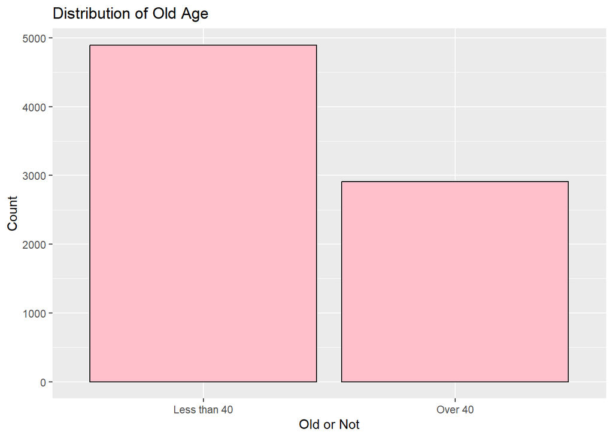

```r
#analysis for oldage
ggplot(reaction, aes(x = factor(oldage, levels = c(0, 1), labels = c("Less than 40", "Over 40")))) +
  geom_bar(fill = "pink", color = "black") +
  labs(title = "Distribution of Old Age",
       x = "Old or Not",
       y = "Count")
```

There are more females than males in this dataset.

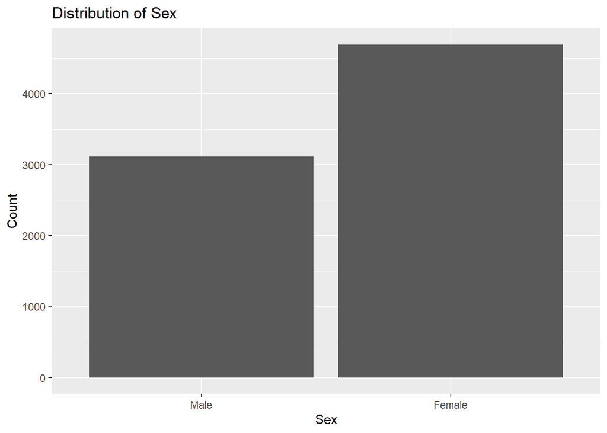

```r
#analysis for sex
ggplot(reaction, aes(x = factor(sex, levels = c(0, 1), labels = c("Male", "Female")))) +
  geom_bar() +
  labs(title = "Distribution of Sex",
       x = "Sex",
       y = "Count")
```

The age of participants is bimodial. There are many who are very young, newer drivers in their teens and twenties and large amounts of drivers within the 65 to 80 age range. This was likely done to compare the two age groups and to get large differences by using such a drastic difference in ages.

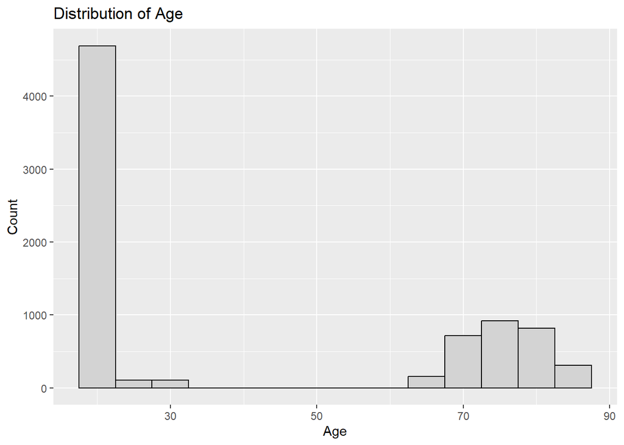

```r
#analysis for age
ggplot(reaction, aes(x = age)) +
  geom_histogram(binwidth = 5, fill = "lightgrey", color = "black") +
  labs(title = "Distribution of Age",
       x = "Age",
       y = "Count")
```

## Bivariate Analysis

When comparing the groups of young and old, we see that each quartile of old has longer reaction times compared to the young boxplot. There is also more variance between the old group compared to the young group.

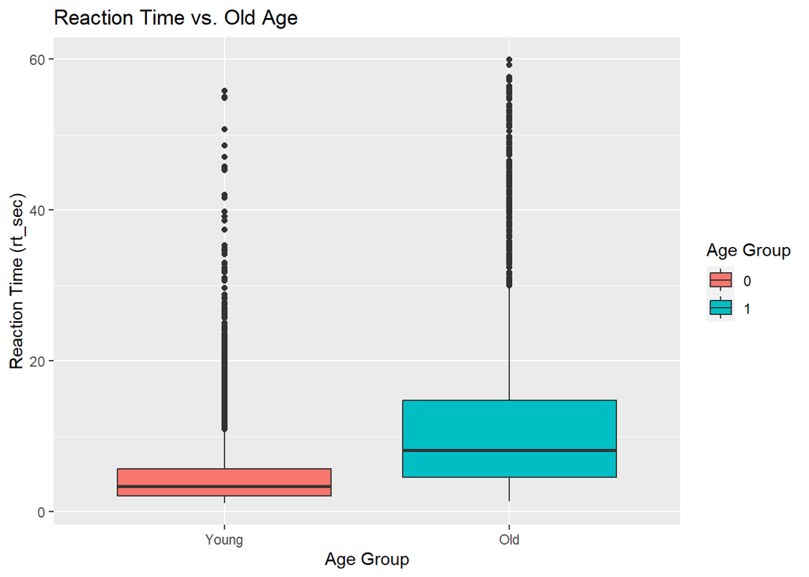

```r
#old vs young reaction time
ggplot(reaction, aes(x = factor(oldage, labels = c("Young", "Old")), y = rt_sec, fill = factor(oldage))) +
  geom_boxplot() +
  labs(title = "Reaction Time vs. Old Age",
       x = "Age Group",
       y = "Reaction Time (rt_sec)",
       fill = "Age Group")
```

Meaning represents how important the picture is when driving. As we would expect, the least meaningful pictures have some of the highest reaction times, while most of the more important pictures have lower reaction times, in general.

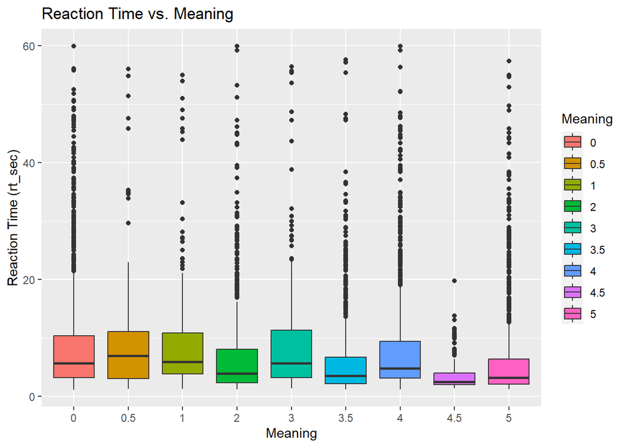

```r
#meaning reaction time
ggplot(reaction, aes(x = factor(meaning), y = rt_sec, fill = factor(meaning))) +
  geom_boxplot() +
  labs(title = "Reaction Time vs. Meaning",
       x = "Meaning",
       y = "Reaction Time (rt_sec)",
       fill = "Meaning")
```

## Analysis

```r
model_int<-lmer(rt_sec ~ 1 + (1|id),data = reaction)
summary(model_int)
```

```
## Linear mixed model fit by REML ['lmerMod']
## Formula: rt_sec ~ 1 + (1 | id)
##    Data: reaction
##
## REML criterion at convergence: 52504.2
##
## Scaled residuals:
##     Min      1Q  Median      3Q     Max
## -1.7983 -0.4633 -0.2542  0.1565  6.9516
##
## Random effects:
##  Groups   Name        Variance Std.Dev.
##  id       (Intercept) 12.31    3.508
##  Residual             53.44    7.310
## Number of obs: 7646, groups:  id, 153
##
## Fixed effects:
##             Estimate Std. Error t value
## (Intercept)   7.4402     0.2957   25.16
```

Fixed Intercept:

The fixed intercept is 7.4402 with a standard error of 0.2957 and a t-value of 25.16. This is the estimated intercept that represents the average reaction time when there are no other predictors in the model.

Intraclass correlation coefficient:

18.8% of the total variation in rt_sec(reaction) are due to differences between participants.

```r
#his example code pulled form lecture 21

model <- lmer(rt_sec ~ meaning + oldage + meaning:oldage + (1 + oldage | id),
               REML = FALSE,
               data = reaction)
```

```
## boundary (singular) fit: see help('isSingular')
```

```r
summary(model)
```

```
## Linear mixed model fit by maximum likelihood  ['lmerMod']
## Formula: rt_sec ~ meaning + oldage + meaning:oldage + (1 + oldage | id)
##    Data: reaction
##
##      AIC      BIC   logLik deviance df.resid
##  52078.6  52134.1 -26031.3  52062.6     7638
##
## Scaled residuals:
##     Min      1Q  Median      3Q     Max
## -1.8885 -0.4663 -0.2182  0.1517  7.0224
##
## Random effects:
##  Groups   Name        Variance Std.Dev. Corr
##  id       (Intercept)  0.000   0.000
##           oldage       5.721   2.392     NaN
##  Residual             52.325   7.234
## Number of obs: 7646, groups:  id, 153
##
## Fixed effects:
##                Estimate Std. Error t value
## (Intercept)     6.26633    0.17901  35.005
## meaning        -0.49462    0.05502  -8.989
## oldage          6.53532    0.43474  15.033
## meaning:oldage  0.05709    0.09132   0.625
##
## Correlation of Fixed Effects:
##             (Intr) meanng oldage
## meaning     -0.815
## oldage      -0.412  0.336
## meaning:ldg  0.491 -0.603 -0.559
## optimizer (nloptwrap) convergence code: 0 (OK)
## boundary (singular) fit: see help('isSingular')
```

```r
anova(model)
```

```
## Analysis of Variance Table
##                npar  Sum Sq Mean Sq  F value
## meaning           1  6050.7  6050.7 115.6359
## oldage            1 18010.2 18010.2 344.1977
## meaning:oldage    1    20.5    20.5   0.3909
```

```r
model.reduced <- lmer(rt_sec ~ meaning + oldage + meaning:oldage + (1 | id),
               REML = FALSE,
               data = reaction)
summary(model.reduced)
```

```
## Linear mixed model fit by maximum likelihood  ['lmerMod']
## Formula: rt_sec ~ meaning + oldage + meaning:oldage + (1 | id)
##    Data: reaction
##
##      AIC      BIC   logLik deviance df.resid
##  52165.6  52207.3 -26076.8  52153.6     7640
##
## Scaled residuals:
##     Min      1Q  Median      3Q     Max
## -1.7489 -0.4693 -0.2088  0.1523  6.9137
##
## Random effects:
##  Groups   Name        Variance Std.Dev.
##  id       (Intercept)  1.809   1.345
##  Residual             52.623   7.254
## Number of obs: 7646, groups:  id, 153
##
## Fixed effects:
##                Estimate Std. Error t value
## (Intercept)     6.26631    0.22601  27.726
## meaning        -0.49474    0.05518  -8.965
## oldage          6.52069    0.37378  17.445
## meaning:oldage  0.05896    0.09157   0.644
##
## Correlation of Fixed Effects:
##             (Intr) meanng oldage
## meaning     -0.647
## oldage      -0.605  0.391
## meaning:ldg  0.390 -0.603 -0.652
```

```r
coef(model.reduced)
```

```
## $id
##     (Intercept)    meaning   oldage meaning:oldage
## 1      6.160973 -0.4947381 6.520688     0.05896009
## 2      6.342838 -0.4947381 6.520688     0.05896009
## 3      7.597167 -0.4947381 6.520688     0.05896009
## 4      6.319438 -0.4947381 6.520688     0.05896009
## 5      5.763916 -0.4947381 6.520688     0.05896009
## 6      6.457271 -0.4947381 6.520688     0.05896009
## 7      6.762184 -0.4947381 6.520688     0.05896009
## 8      6.091248 -0.4947381 6.520688     0.05896009
## 9      5.734934 -0.4947381 6.520688     0.05896009
## 10     5.997999 -0.4947381 6.520688     0.05896009
## 11     5.606599 -0.4947381 6.520688     0.05896009
## 12     6.885588 -0.4947381 6.520688     0.05896009
## 13     6.124962 -0.4947381 6.520688     0.05896009
```

[output cut: 143 more lines]

```r
anova(model,model.reduced)
```

```
## Data: reaction
## Models:
## model.reduced: rt_sec ~ meaning + oldage + meaning:oldage + (1 | id)
## model: rt_sec ~ meaning + oldage + meaning:oldage + (1 + oldage | id)
##               npar   AIC   BIC logLik deviance  Chisq Df Pr(>Chisq)
## model.reduced    6 52166 52207 -26077    52154
## model            8 52079 52134 -26031    52063 91.062  2  < 2.2e-16 ***
## ---
## Signif. codes:  0 '***' 0.001 '**' 0.01 '*' 0.05 '.' 0.1 ' ' 1
```